# Inntektssikring

Kap. 6 i Barr

Mikko Moilanen

2026-03-24

## Tema 4 - Inntektssikring

- mål: å sikre en akseptabel inntekt når arbeidsinntekten faller bort av årsaker den enkelte ikke har kontroll over, som arbeidsledighet, uførhet eller sykdom
- utformingen av inntektssikringssystemet kan bidra til å svekke de økonomiske insentivene til å delta på arbeidsmarkedet
- vi vil først gå gjennom de teoretiske argumentene hvorfor det offentlige tilbyr inntekts- og sosialforsikring
- deretter vil vi se på positive og negative insentiveffekter av trygd
  - ser på behovet av trygd og insentivproblemer med slike støtteordninger

## Et meget viktig tema

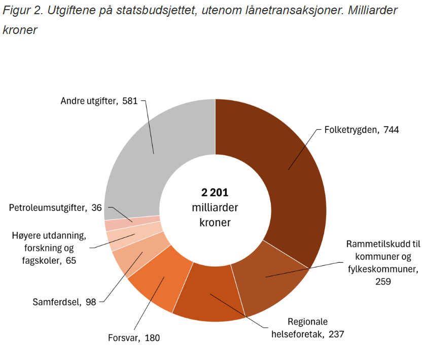

Kilde: Statsbudsjettet 2026

Det største utgiftsområdet er ytelser fra folketrygden, blant annet alderspensjon, uføretrygd, sykepenger, arbeidsavklaringspenger, dagpenger, foreldrepenger og enkelte helsestønader.

## Offentlige sosiale ytelser per innbygger i Europa

[figure not shown]

## Et meget viktig tema

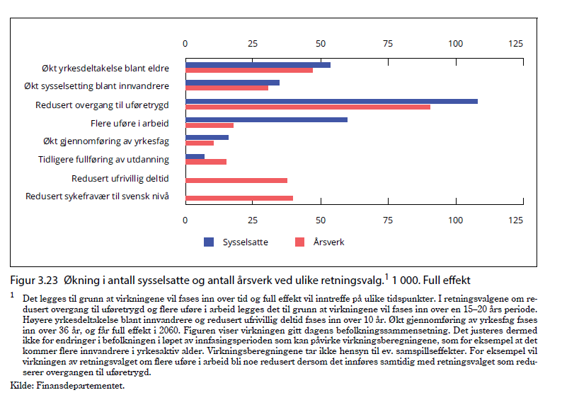

## Velferdssstaten

[figure not shown]

Nettavisen 06.09.2024

## Velferdsstaten

- «Arbeidslinja»
  - økt deltakelse i arbeidslivet
  - har vært en sentral målsetting i oppbyggingen av den norske velferdsstaten
- Inntektssikring
  - Arbeidsledighetstrygd, arbeidsavklaringspenger(AAP), sykepenger, uføretrygd (kap 6), alderspensjon (kap 7)
  - å sikre inntekt mot uforutsette hendelser
  - **utbetalinger er betinget på at en har betalt inn til folketrygden**
- Sosialhjelp (kap 8) –
  - Fattigdom: enpersonshusholdning har mindre enn 50 prosent av medianinntekt i tre år
- Universelle ordninger (kap 8) –
  - Grunnpensjoner, barnetrygd

**Ikke forveksle kunnskap om institusjoner med å forstå den underliggende økonomiske teorien!**

## Hva er de store spørsmålene?

- Mål:
  - fattigdomsbekjempelse
  - forsikring
  - konsumglatting
- Spørsmål:
  - **Hvorfor er det offentlig organisert?**
  - **Er dette forsikring?**

## Inntektssikring

[figure not shown]

[figure not shown]

## Arbeidsledighetstrygd (dagpenger)

- For å ha krav på dagpenger må man ha fått redusert arbeidstiden med minst 50 prosent
- krav til at man har tjent mer enn 1,5G (G=grunnbeløp, 130 161 kr, i folketrygden) de siste 12 månedene
- eller minst 3G de siste 36 månedene
- må være registrert som arbeidssøker
- dagpengene er 2,4 promille av dagpengegrunnlaget
  - tilsvarer i gjennomsnitt 62,4 prosent av tidligere inntekt før skatt
- Dagpenger beregnes ikke av inntekter som er større enn 6 G
  - Maksimal dagpengeutbetaling (2024) blir dermed 470-480 000 kroner pr.år
- Dagpengegrunnlaget består av arbeidsinntekt og eventuelle folketrygdytelser (dagpenger, foreldrepenger ved fødsel og adopsjon, omsorgspenger, opplæringspenger, pleiepenger,svangerskapspenger, sykepenger)

## Dagpenger

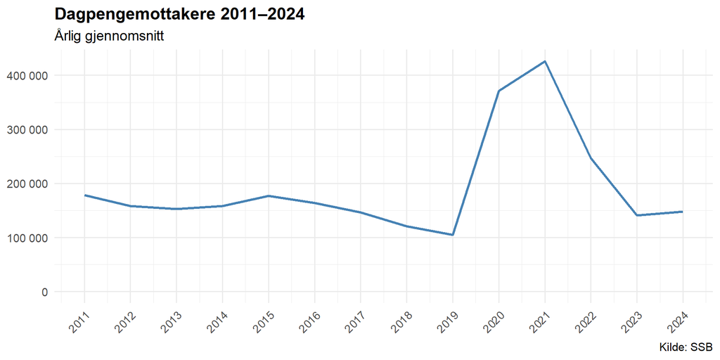

# De helserelaterte ytelsene

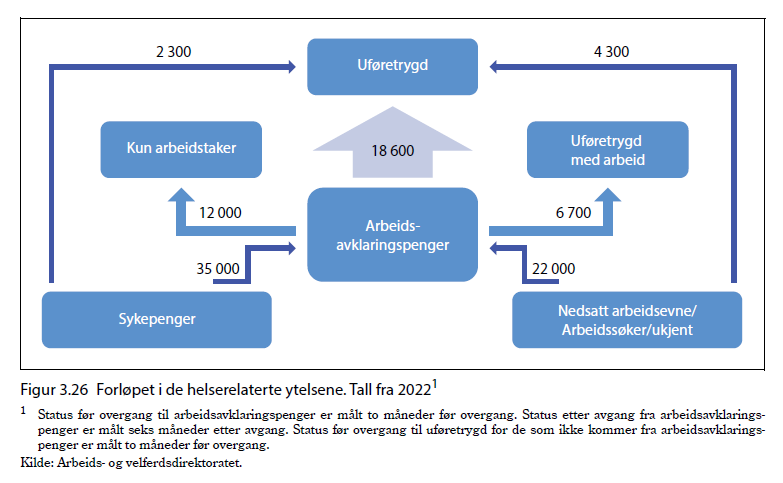

## Sykepenger

- Arbeidsgiveren utbetaler sykepenger for de første 16 kalenderdagene
- 100 % dekning: man kan få sykepenger som tilsvarer full lønn fra arbeidsgiveren din, men man har ikke rett til et sykepengegrunnlag som overstiger 6G
- 52 uker makstid
- Egenmelding betyr at du melder fra til arbeidsgiveren din om at du er syk, uten at du leverer sykmelding
- Ved gradert (delvis) sykmelding har du rett til sykepenger for den delen du er syk
  - sykepengene kan graderes fra 100 prosent og ned til 20 prosent

## Sykefravær, egenmeldt og legemeldt

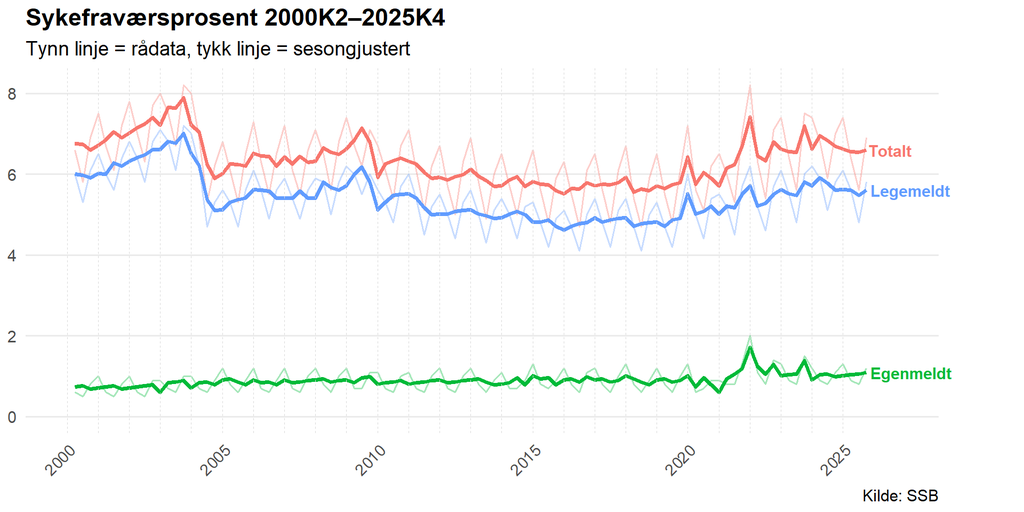

## Sykefravær pr. kjønn

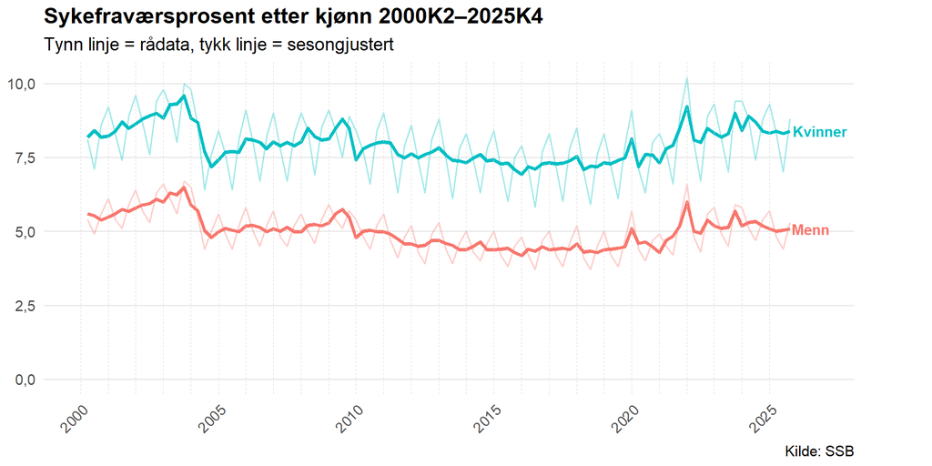

## Hva blir folk syk av

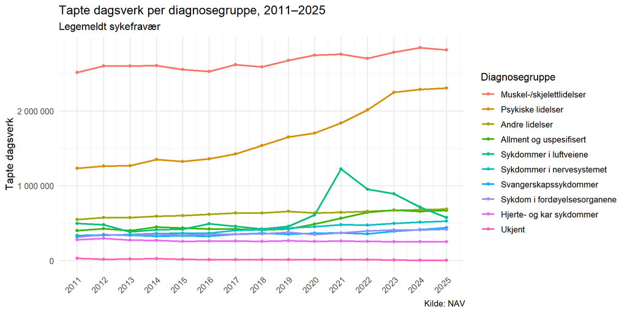

## Sykefravær med diagnoser under gruppen psykiske lidelser

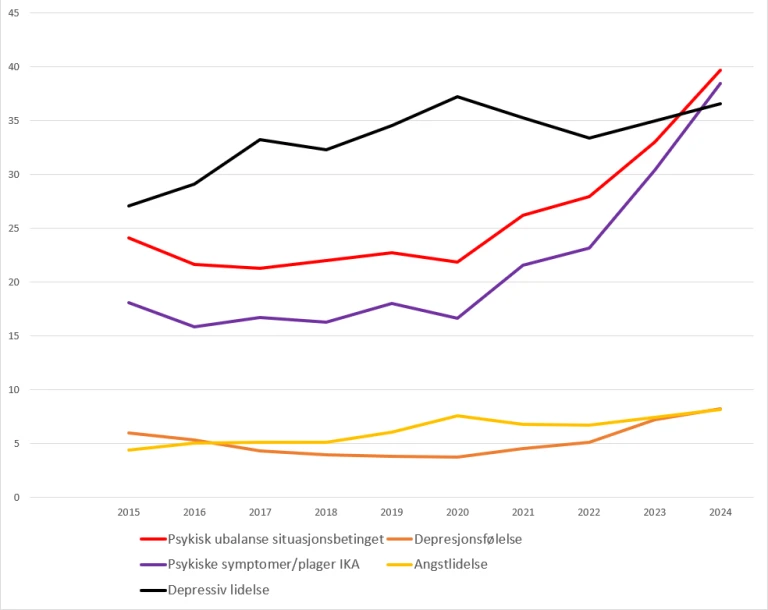

Sykefravær med enkelte diagnoser under gruppen psykiske lidelser. Andel tapte dagsverk per 10 000 avtalte dagsverk. 2. kvartal i årene 2015 – 2024. Kilde: NAV

## Norge har høyt sykefravær

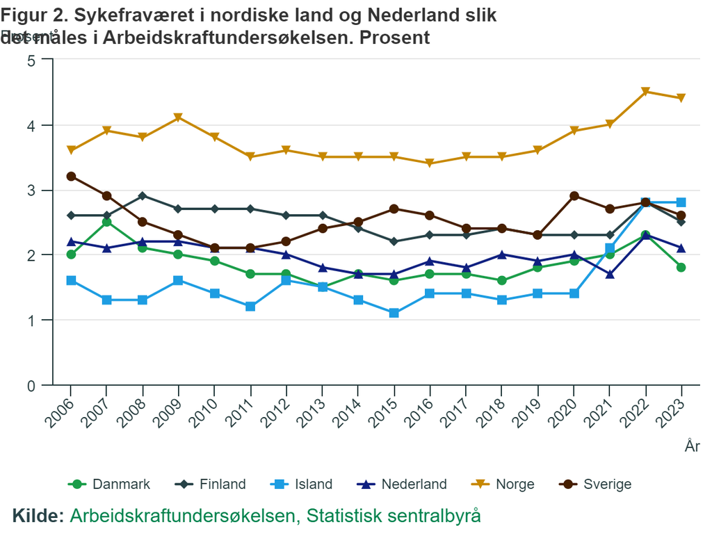

## Arbeidsavklaringspenger

- skal sikre inntekt til personer mellom 18 og 67 år som på grunn av **sykdom**, **skade** eller **lyte** har fått nedsatt arbeidsevne
  - Arbeidsevnen skal være nedsatt med minst halvparten
- rettet mot personer med redusert arbeidsevne, og der det er mulighet for at arbeidsevnen kan bli bedre gjennom behandling, arbeidsrettede tiltak eller oppfølging fra NAV
- **Målet med ordningen er å skaffe eller beholde arbeid og dermed unngå overgang til uføretrygd**

## Arbeidsavklaringspenger

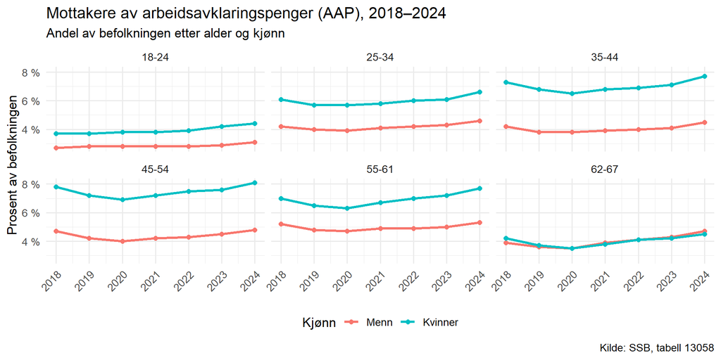

## Uføretrygd

- for å ha rett til å få uføretrygd, må sykdom og/eller skade være hovedårsaken til at man har nedsatt arbeids- og inntektsevne
- må som hovedregel fylle disse vilkårene:
  - må være mellom 18 og 67 år
  - må ha vært medlem av folketrygden de siste 5 årene før du ble syk eller skadet
  - må ha minst 50 prosent redusert arbeids- og inntektsevne
- må ha gjennomført
  - hensiktsmessig behandling som kan bedre arbeidsevnen
  - arbeidsrettede tiltak for å bedre inntektsevnen og avklare hvor mye man kan jobbe
- sammenlignet med andre land er det en høy andel av den voksne befolkningen i Norge som mottar uføreytelser

## Uføretrygd

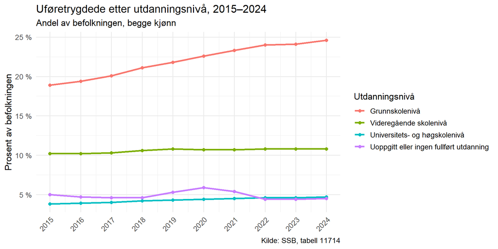

## Størst økning blant unge voksne uføre

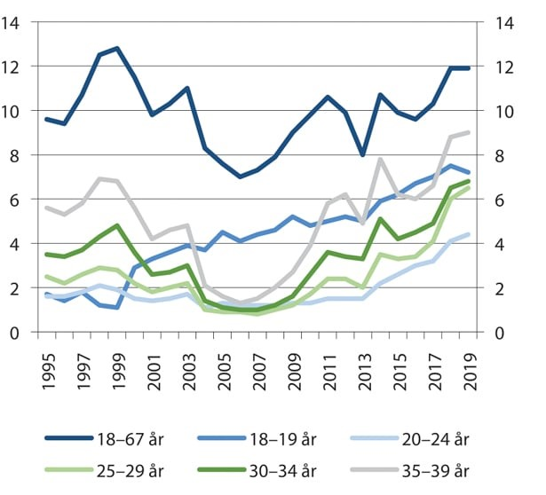

Nye mottakere av uføretrygd per 1000 ikke-ufør person i samme aldersgruppe. 1995–2019. Kilde: Arbeids- og velferdsdirektoratet

## Uførhet og diagnose

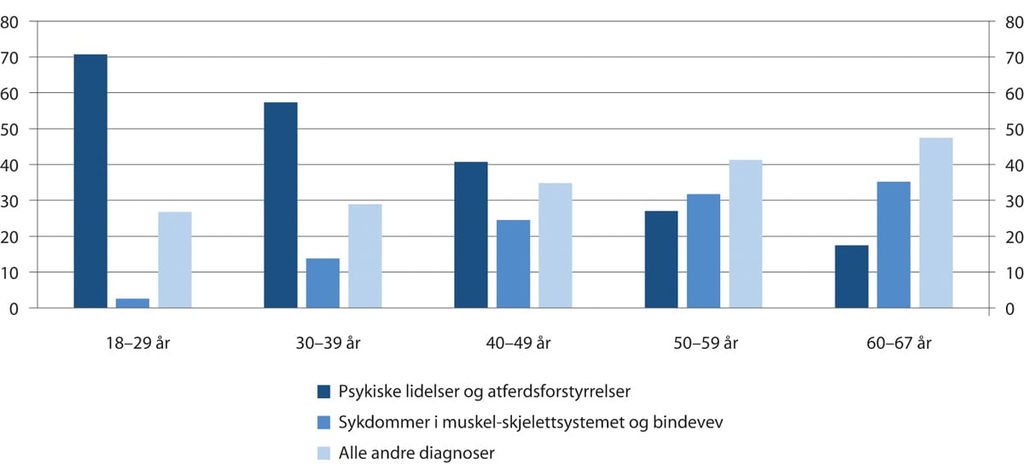

Nye uføre etter utvalgte diagnose- og aldersgrupper. Prosent. 1. halvår 2016. Kilde: Arbeids- og velferdsdirektoratet

## Høy andel uføretrygdede sammenlignet med andre land

- sammenlignet med andre land er det en høy andel av den voksne befolkningen i Norge som mottar uføreytelser
- det er ingenting som tyder på at den generelle helsetilstanden er dårligere i Norge enn i andre land
- institusjonelle forskjeller som forklarer forskjellene i uføreandeler

## Argument for offentlig **tvungen** sosialforsikring: Effektivitet 1: Regulering

- Hvorfor er medlemskapet obligatorisk?
  - Eksternaliteter
    - I mange tilfeller er beslutningen om å forsikre overlatt til individet, siden kostnadene ved ikke-forsikring faller på den enkelte
    - Men hvis noen velger å ikke forsikre seg mot inntektstap på grunn av arbeidsledighet eller dårlig helse, vil kostnadene falle på
      - ektefeller, barn og familie
      - skattebetalerne, for eksempel gjennom økende kriminalitet → **negative eksternaliteter**
    - Når en aktivitet forårsaker en negativ eksternalitet, er en form for intervensjon en Pigou-skatt
    - Her er imidlertid målet å **hindre** manglende forsikring

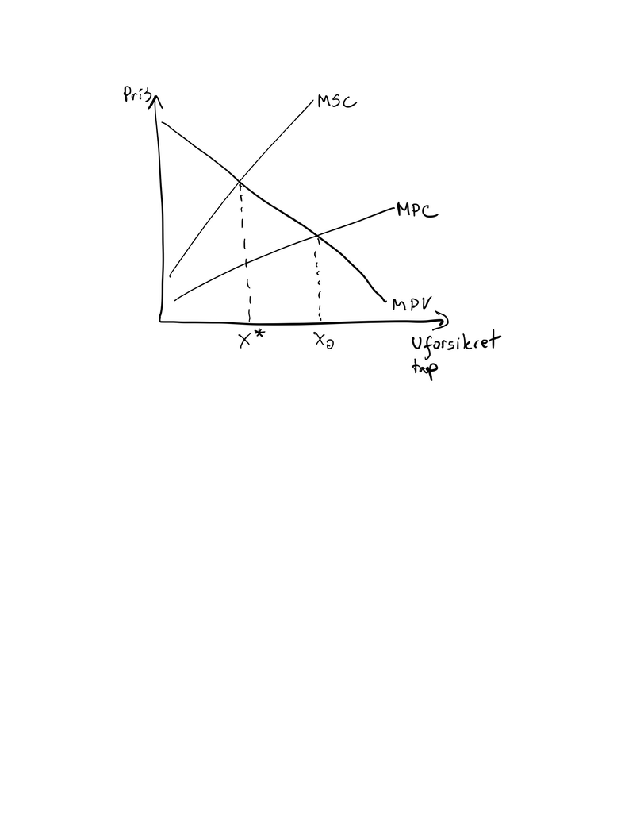

    - Å gjøre forsikring obligatorisk (dvs. regulering) vil derfor være mest effektivt
  - I sum er det store effektivitetsargumentet for å gjøre medlemskap obligatorisk (=regulering) at **uforsikrede tap kan påføre kostnader (= negative eksternaliteter) for andre**

## Argument for offentlig sosialforsikring: Effektivitet 2: offentlig tilbud

### Repetisjon: Privat tilbud av forsikring, forutsetninger

$$\pi_i = (1+α) p_iL$$

- De individuelle sannsynlighetene for ulykke/skade ($p_i$) er uavhengig av hverandre (ingen systematisk risiko)
- Må ha usikkerhet, dvs. manglende kunnskap om framtidig utfall $p_i \le 1$
  - om $p_i = 1$, da blir $\pi = (1+α)L > L$
- Risiko, ikke usikkerhet (sannsynlighet må være kjent eller mulig å estimere (forsikringsselskapet må vite gjennomsnittlig $p_i$)
- Ingen asymmetrisk informasjon
- ingen ugunstig utvalg
- ingen adferdsrisiko
  - kan påvirke $p_i$ (ex ante -atferdsrisiko)
    - forsikringstakeren kan påvirke sannsynlighet for tap eller størrelse på potensielt tap, gjennom strategisk adferdsendring
    - for eksempel ingen forebygging

### Arbeidsledighetstrygd (dagpenger): er forutsetningene for privat forsikring oppfylt?

- Det finnes systematisk risiko (konjunkturer)
- Framtidig utfall usikkert, $p_i < 1$
- Risikoen $p_i$ kan estimeres
- Problem med asymmetrisk informasjon
  - Uheldig utvalg
    - lavrisikogruppen vil ikke kjøpe forsikring
  - Adferdsrisiko
    - forsikringstakeren kan påvirke $p_i$ => hva er den rette forsikringspremien?
      - Et sentralt spørsmål er hvor kostbart (økonomisk og psykisk) det er for en person å forbli arbeidsledig
        - den psykiske kostnaden for den enkelte kan være høy, og **arbeidsledighet er forårsaket av mangel på jobber**
          - en forsikringsbar risiko
        - den psykiske kostnaden er lav, og den enkelte forblir **arbeidsledig delvis etter eget valg**
          - en ikke-forsikringsbar risiko
        - $p_i$ kan manipuleres av den forsikrede personen på måter forsikringsgiveren ikke kan overvåke, noe som gjør det umulig for forsikringsselskapet å beregne en premie (kan også påvirke ex post -atferdsrisiko) = redusere jobbsøkintensiteten)
  - problemet med asymmetrisk informasjon er verre for arbeidsledighetstrygd enn for sykepenger og uføretrygd
    - økonomisk teori: privat marked kan derfor ikke tilby arbeidsledighetstrygd

## 6.2.4 Argument for offentlig sosialforsikring: Rettferdighet

- Horisontal ulikhet handler om minimumsstandarder og/eller lik tilgang til dem
  - om forbrukere er godt informert –> ingen grunn til offentlig inngrep pga. horisontal ulikhet
  - om de er dårlig informert, kan man argumentere for offentlig sosialforsikring både på grunn av rettferdighet og effektivitet
- Vertikal ulikhet handler om omfordeling fra rik til fattig
  - trygdessystemet er omfordelende
  - fordelingsmålene burde generelt oppnås gjennom inntektsoverføringer

## 6.3 Store spørsmål

- Skal sosialforsikringen være offentlig? **Ja**
  - effektivitetsargumentene hviler på
    - **negative eksternaliteter** (rettferdiggjør **tvungen** sosialforsikring), og
    - **asymmetrisk informasjon** på tilbudssiden av forsikringsmarkedet (**rettferdiggjør offentlig tilbud**)
      - en svakere argument for sykepenger enn for de andre ytelsene
  - De viktigste rettferdighetsargumentene:
    - de fattige kan føle seg mindre stigmatisert av forsikring
    - hvis forsikring tilbys offentlig av effektivitetshensyn, kan den brukes som en omfordelingsanordning
  - Disse argumentene er overbevisende
    - noen forsikringer kunne tilbys av privat sektor
      - for eksempel kortsiktige sykepenger
- Gir staten den optimale mengden forsikring? **Nei**
  - trygden som tilbys er et **gjennomsnitt** som ikke tar hensyn til forskjeller i preferanser
  - spørsmålet er ikke om sosialforsikring er optimal, men om hvis den er godt utformet, er den mindre ineffektiv enn frimarkedsløsning
- Er Folketrygden en forsikring?
  - Ytelsen er ikke knyttet til individuell risiko (fordi den er avhengig av tidligere inntekt)
    - Retten til ytelse er ikke bare avhengig av forekomsten av den forsikrede hendelsen
  - Ordningens finansiering er ikke basert på vurderinger av risiki av forskjellige slag (sannsynlighetsfordelinger)
  - Kontrakten er ikke fullstendig spesifisert (risikoen som dekkes kan endres over tid)